# Fish Market Project

### Exploratory Data Analysis:

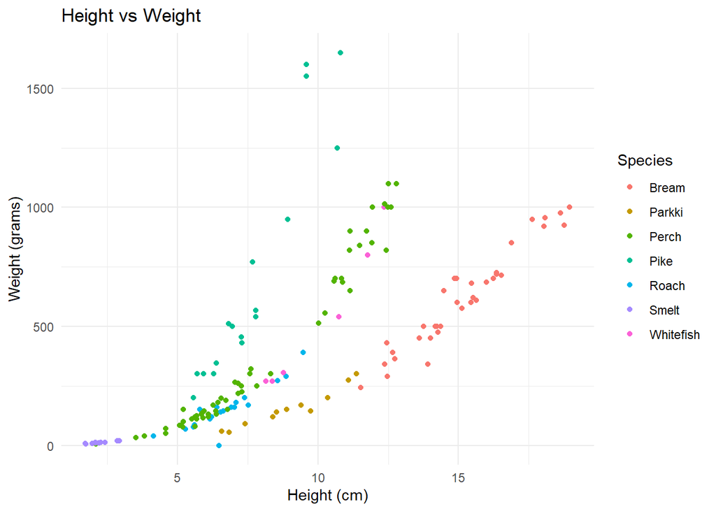

Note: Since there are about 3 different lines made of the points, we can say that some species definitely have the same comparison between weight and height.

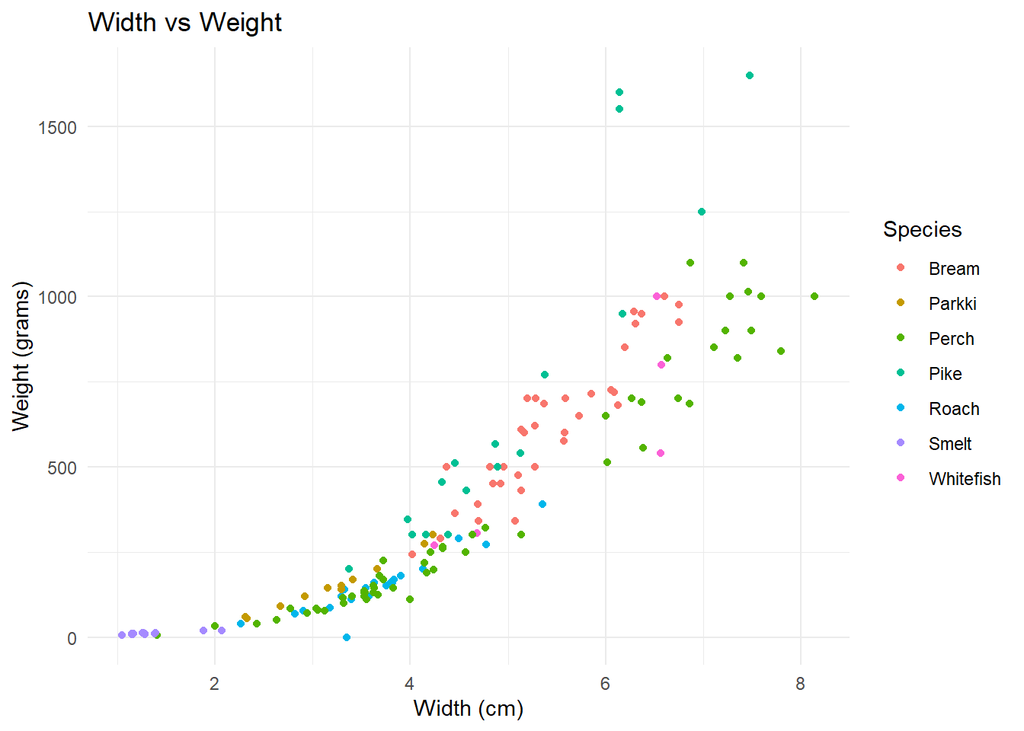

Note: Based off this scatter plot, we can see that each species follows the same pattern with width vs weight.

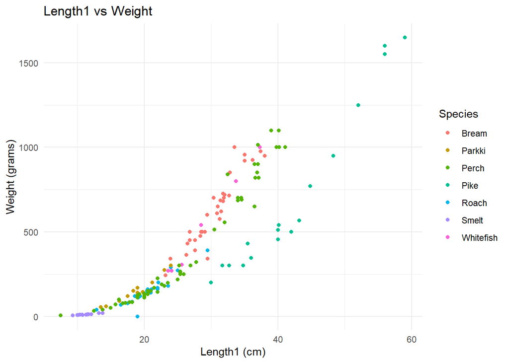

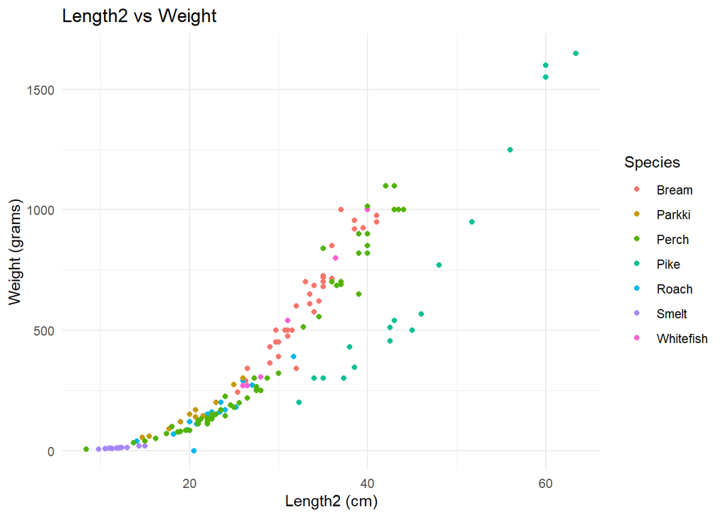

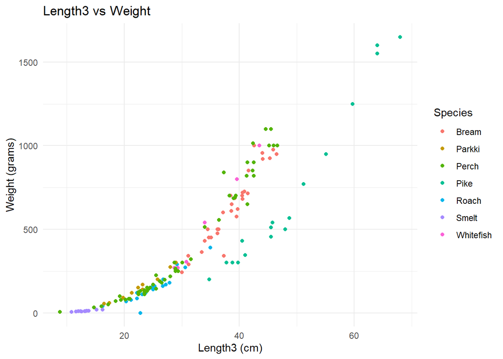

Note: for all the scatter plots of length vs weight, you can see that the all the species beside Pike are about the same.

### Model Construction:

### Model 1 Construction: Lasso Regression

My first model used Height, Width, Length1, and grouped_species as variables, with Width and Length1 being polynomial regression. I mutated my data to make grouped_species which consists of Pike on it’s own, Perch, Whitefish, Roach and Smelt in Group1, and Bream and Parkki in Group2.

Note: Here I did lambda perimeter tuning in order to find the best value of lambda for my first model.

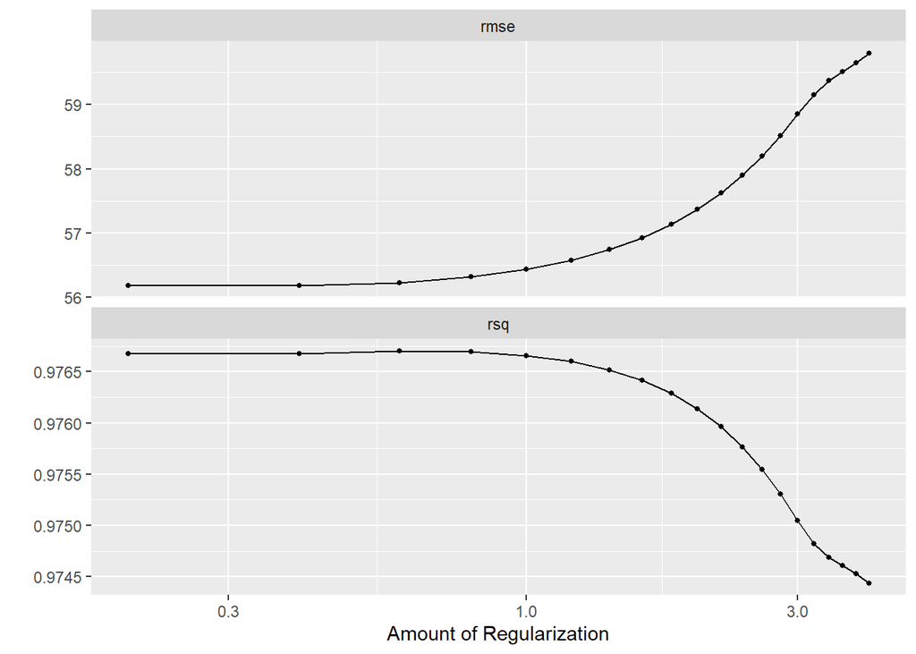

Note: I found the value 0.4 to be the best for lambda in my first model.

```
## # A tibble: 5 × 7
##   penalty .metric .estimator  mean     n std_err .config
##     <dbl> <chr>   <chr>      <dbl> <int>   <dbl> <chr>
## 1     0.4 rmse    standard    56.2    10    4.57 Preprocessor1_Model02
## 2     0.2 rmse    standard    56.2    10    4.57 Preprocessor1_Model01
## 3     0.6 rmse    standard    56.2    10    4.59 Preprocessor1_Model03
## 4     0.8 rmse    standard    56.3    10    4.60 Preprocessor1_Model04
## 5     1   rmse    standard    56.4    10    4.63 Preprocessor1_Model05
```

Note: This shows the coefficients for my variables in my first model.

```
## # A tibble: 8 × 3
##   term                   estimate penalty
##   <chr>                     <dbl>   <dbl>
## 1 (Intercept)               105.      0.4
## 2 Height                    174.      0.4
## 3 grouped_species_Group2    -44.0     0.4
## 4 grouped_species_Pike      -37.3     0.4
## 5 Width_poly_1              421.      0.4
## 6 Width_poly_2              471.      0.4
## 7 Length1_poly_1           2442.      0.4
## 8 Length1_poly_2           1106.      0.4
```

Note: This shows the RMSE for my first model.

```
## # A tibble: 1 × 3
##   .metric .estimator .estimate
##   <chr>   <chr>          <dbl>
## 1 rmse    standard        33.7
```

Note: This shows the RSQ for my first model.

```
## # A tibble: 1 × 3
##   .metric .estimator .estimate
##   <chr>   <chr>          <dbl>
## 1 rsq     standard       0.990
```

### Model 1 Construction: Least Squares Regression

This model is a least squares model using Height, Width, Length1, and grouped_species. Width and Length1 are polynomial regression.

Note: This shows the RMSE and RSQ for my model

```
## # A tibble: 2 × 6
##   .metric .estimator   mean     n std_err .config
##   <chr>   <chr>       <dbl> <int>   <dbl> <chr>
## 1 rmse    standard   56.1      10 4.56    Preprocessor1_Model1
## 2 rsq     standard    0.977    10 0.00508 Preprocessor1_Model1
```

Note: Shows the coeffients for my variables and their p-values.

```
## # A tibble: 1 × 12
##   r.squared adj.r.squa…¹ sigma stati…²  p.value    df logLik   AIC   BIC devia…³
##       <dbl>        <dbl> <dbl>   <dbl>    <dbl> <dbl>  <dbl> <dbl> <dbl>   <dbl>
## 1     0.981        0.979  53.5    800. 7.25e-92     7  -638. 1294. 1319. 317124.
## # … with 2 more variables: df.residual <int>, nobs <int>, and abbreviated
## #   variable names ¹adj.r.squared, ²statistic, ³deviance
```

```
## # A tibble: 8 × 5
##   term                   estimate std.error statistic  p.value
##   <chr>                     <dbl>     <dbl>     <dbl>    <dbl>
## 1 (Intercept)                83.2      56.2      1.48 1.42e- 1
## 2 Height                    187.       30.5      6.15 1.27e- 8
## 3 grouped_species_Group2    -52.1      17.1     -3.05 2.86e- 3
## 4 grouped_species_Pike      -38.0      15.3     -2.48 1.46e- 2
## 5 Width_poly_1              323.      297.       1.09 2.80e- 1
## 6 Width_poly_2              466.       78.0      5.97 2.92e- 8
## 7 Length1_poly_1           2453.      356.       6.89 3.55e-10
## 8 Length1_poly_2           1122.      110.      10.2  1.29e-17
```